# NegativeMetabolomics

Aroosha Raja

## Load Libraries

This section loads necessary libraries #Working directory: setwd(“/Users/araja2/Desktop/Metabolomics”)

```r
library(tidyverse)
library(dplyr)
library(FactoMineR)
library(factoextra)
library(imputeTS)
library(cluster)
```

```r
library(impute)
library(ggplot2)
library(mice)
library(mixOmics)
library(limma)
library(reshape2)
library(ggrepel)
library(ggplot2)
library(ggpubr)
library(readxl)
conflicted::conflicts_prefer(dplyr::filter)
```

```
## [conflicted] Will prefer dplyr::filter over any other package.
```

This section defines global color scheme which we used for plots within our analysis

```r
plot_colors <- c(
  "0µM ERAP1 inhibitor" = "#E69F00",
  "10µM ERAP1 inhibitor" = "#0072B2",
  "50µM ERAP1 inhibitor" = "#009E73",
  "KO" = "#999933",
  "Reference" = "red"
)

volcano_colors <- c(
  "Upregulated" = "#D32F2F",
  "Downregulated" = "#1976D2",
  "Not Significant" = "grey80"
)
boxplot_colors <- c(
  "0µM ERAP1 inhibitor" = "#E69F00",
  "10µM ERAP1 inhibitor" = "#0072B2",
  "50µM ERAP1 inhibitor" = "#009E73",
  "KO" = "red"
)
```

This section includes Data import and preprocessing including missing (NA) value imputation.

```r
data1<-read_excel("P-24XXX_ArooshaNetherlands_HIMet_finalnew.xlsx", sheet = 2)
df1 <- as.data.frame(data1)
df1 <- df1 %>%
  slice(-1:-8)
colnames(df1) <- as.character(unlist(df1[1, ]))
df1 <- df1[-1, ]
sample_cols <- grep("id|PRCS|STRD|MTRX|CMTRX|WT|KO", names(df1), value = TRUE)
filtered_cols <- sample_cols[grepl("^id$|^Btc", sample_cols)]
pca_data <- df1[, filtered_cols[filtered_cols != "id"]]
pca_data <- as.data.frame(lapply(pca_data, function(x) as.numeric(as.character(x))))
```

[output not shown]

```r
imputed_data <- mice(pca_data, m = 1, method = 'rf', seed = 500)
imputed_numeric_data <- complete(imputed_data)
id_column <- df1[, "id"]
complete_data <- cbind(id = id_column, imputed_numeric_data)
filtered_columns <- grepl("CMTRX|WT_DMSO|WT_10uM|WT_50uM|KO|^id$", colnames(complete_data))
filtered_data <- complete_data[, filtered_columns]
transposed_data <- as.data.frame(t(filtered_data[, -1]))
colnames(transposed_data) <- filtered_data$id
#Extract phenotype labels only from relevant columns (exclude "id")
phenotype_labels <- gsub("^.*_(CMTRX|WT_DMSO|WT_10uM|WT_50uM|KO)_.*$", "\\1", colnames(filtered_data))
phenotype_labels <- phenotype_labels[phenotype_labels %in% c("CMTRX", "WT_DMSO", "WT_10uM", "WT_50uM", "KO")]
transposed_data$Phenotype <- phenotype_labels
transposed_data <- transposed_data[, c("Phenotype", setdiff(names(transposed_data), "Phenotype"))]
```

The following section includes the scaling of data using Variable Stability Scaling (VAST) to stabilise the variance across variables while preserving the metabolites having higher mean intensities.

```r
numeric_data <- transposed_data[, sapply(transposed_data, is.numeric)]
vast_scaling <- function(x) {
  variable_mean <- mean(x, na.rm = TRUE)
  variable_sd <- sd(x, na.rm = TRUE)
  scaled <- ((x - variable_mean) / variable_sd) * (variable_mean / variable_sd)
  return(scaled)
}
vast_scaled_data <- as.data.frame(lapply(numeric_data, vast_scaling))
vast_scaled_data <- data.frame(Phenotype = transposed_data$Phenotype, vast_scaled_data)
rownames(vast_scaled_data) <- rownames(numeric_data)
```

Principle component Analysis:

```r
metabolite_data1 <- vast_scaled_data[, -1]
metabolite_data1 <- as.data.frame(lapply(metabolite_data1, as.numeric))
rownames(metabolite_data1) <- rownames(vast_scaled_data)
unique_labels <- make.unique(as.character(phenotype_labels))
rownames(metabolite_data1) <- unique_labels
pca_result <- prcomp(metabolite_data1, scale. = FALSE)
summary(pca_result)
```

```
## Importance of components:
##                            PC1     PC2      PC3      PC4      PC5     PC6
## Standard deviation     56.5714 31.7025 26.51675 22.64456 21.51414 20.3182
## Proportion of Variance  0.3465  0.1088  0.07613  0.05552  0.05012  0.0447
## Cumulative Proportion   0.3465  0.4553  0.53147  0.58699  0.63711  0.6818
##                             PC7      PC8      PC9     PC10     PC11     PC12
## Standard deviation     18.38747 14.63066 14.26156 13.84732 13.53719 13.32493
## Proportion of Variance  0.03661  0.02318  0.02202  0.02076  0.01984  0.01922
## Cumulative Proportion   0.71841  0.74159  0.76361  0.78437  0.80422  0.82344
##                           PC13     PC14     PC15     PC16     PC17    PC18
## Standard deviation     12.9635 12.50096 12.26642 11.77839 11.08018 10.6584
## Proportion of Variance  0.0182  0.01692  0.01629  0.01502  0.01329  0.0123
## Cumulative Proportion   0.8416  0.85856  0.87485  0.88987  0.90316  0.9155
##                            PC19     PC20     PC21    PC22    PC23    PC24
## Standard deviation     10.41648 10.31226 10.02512 9.66705 9.42893 8.65469
## Proportion of Variance  0.01175  0.01151  0.01088 0.01012 0.00963 0.00811
## Cumulative Proportion   0.92721  0.93873  0.94961 0.95973 0.96935 0.97746
##                          PC25    PC26    PC27      PC28
## Standard deviation     8.5402 8.46402 7.97288 2.784e-14
## Proportion of Variance 0.0079 0.00776 0.00688 0.000e+00
## Cumulative Proportion  0.9854 0.99312 1.00000 1.000e+00
```

```r
num_points <- nrow(pca_result$x)
cat("Number of metabolites represented in PCA plot:", num_points, "\n")
```

```
## Number of metabolites represented in PCA plot: 28
```

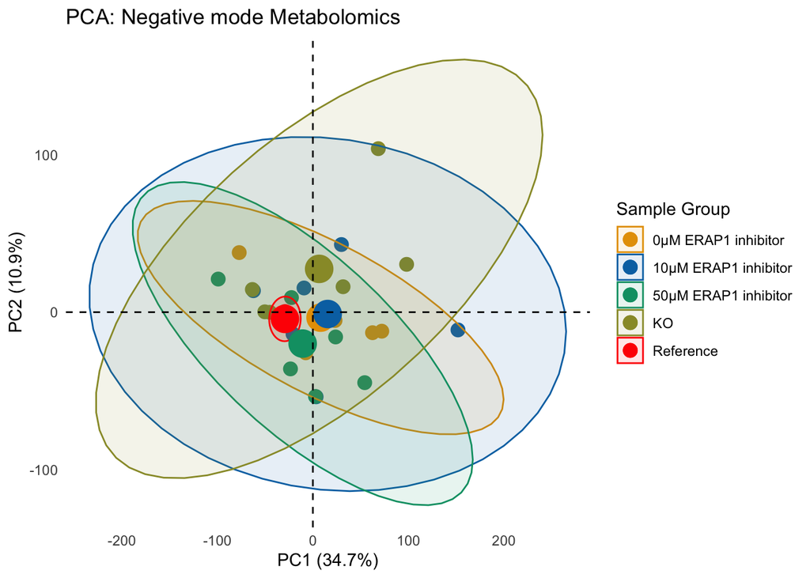

```r
sample_labels <- case_when(
  grepl("KO", rownames(metabolite_data1)) ~ "KO",
  grepl("CMTRX", rownames(metabolite_data1)) ~ "Reference",
  grepl("WT_DMSO", rownames(metabolite_data1)) ~ "0µM ERAP1 inhibitor",
  grepl("WT_10uM", rownames(metabolite_data1)) ~ "10µM ERAP1 inhibitor",
  grepl("WT_50uM", rownames(metabolite_data1)) ~ "50µM ERAP1 inhibitor",
  TRUE ~ "Other"
)
sample_labels <- factor(sample_labels, levels = names(plot_colors))
#pca_plot <- fviz_pca_ind(pca_result, axes = c(1, 2), geom = c("point"), col.ind = sample_labels,
                         #palette = c("#E69F00", "#0072B2", "#009E73", "#999933", "red"),
                         #title = "PCA", pointsize = 4,  legend.title = "Sample Group", addEllipses = TRUE)
####PCA plot#####
pca_plot <- fviz_pca_ind(pca_result,
                         axes = c(1, 2),
                         geom = "point",
                         col.ind = sample_labels,
                         palette = plot_colors,
                         title = "PCA: Negative mode Metabolomics",
                         pointsize = 4,
                         legend.title = "Sample Group",
                         addEllipses = TRUE) + theme_minimal() +
  theme(panel.grid = element_blank()) +
  scale_shape_manual(values = rep(16, length(unique(sample_labels)))) +
  guides(col = guide_legend(override.aes = list(shape = 16, size = 4))) +
  xlab("PC1 (34.7%)") +
  ylab("PC2 (10.9%)")
pca_plot
```

```r
#ggsave("Negative_pca_plot.svg", plot = pca_plot, width = 8, height = 6, device = "svg")
```

[figure not shown]

This section includes LIMMA Differential expression Analysis to find metabolites in comparison of 0µM ERAP1 inhibitor with 10µM ERAP1 inhibitor, 50µM ERAP1 inhibitor treated and ERAP1 Knockout cells. Here WT_DMSO represents 0µM ERAP1 inhibitor, WT_10: 10µM ERAP1 inhibitor, WT_50: 50µM ERAP1 inhibitor and KO repreents: ERAP1 Knockout

[output not shown]

[output not shown]

[output not shown]

[output not shown]

This section includes the Boxplot analysis using ANOVA for key metabolite features to compare between conditions under study

[figure not shown]

```r
selected_ids <- c(
  "HIMETNEGFT08036", "HIMETNEGFT10931", "HIMETNEGFT11069", "HIMETNEGFT10768",
  "HIMETNEGFT09778")

metabolite_names <- c(
  "HIMETNEGFT08036" = "(R)-lactic acid [M-H]-",
  "HIMETNEGFT10931" = "aconitic acid [M-H]-",
  "HIMETNEGFT11069" = "citric acid [M-H]-",
  "HIMETNEGFT10768" = "Glucose/Fructose-P [M-H]-",
  "HIMETNEGFT09778" = "succinic acid [M-H]-"
)
filtered_data1 <- complete_data %>% filter(id %in% selected_ids)
long_df <- filtered_data1 %>%
  pivot_longer(cols = -id, names_to = "Sample", values_to = "Concentration") %>%
  mutate(
    Condition = case_when(
      str_detect(Sample, "WT_DMSO") ~ "0µM ERAP1 inhibitor",
      str_detect(Sample, "WT_10uM") ~ "10µM ERAP1 inhibitor",
      str_detect(Sample, "WT_50uM") ~ "50µM ERAP1 inhibitor",
      str_detect(Sample, "KO") ~ "KO",
      TRUE ~ NA_character_
    ),
    Concentration = as.numeric(Concentration),
    Concentration = log10(Concentration + 1),
    FacetLabel = metabolite_names[id]
  ) %>%
  filter(!is.na(Condition) & !is.na(FacetLabel))

g <- ggplot(long_df, aes(x = Condition, y = Concentration, color = Condition)) +
  geom_boxplot(outlier.shape = NA, size = 1.5, color = "black", fill = NA) +
  geom_jitter(width = 0.2, alpha = 0.8, size = 3, shape = 16, show.legend = TRUE) +
  stat_compare_means(
    method = "anova",
    label = "p.format",
    label.y.npc = 0.95,
    size = 4,
    fontface = "bold",
    color = "black"
  ) +
  scale_color_manual(values = boxplot_colors) +
  facet_wrap(~ FacetLabel, scales = "free_y", nrow = 4, ncol = 5) +
  labs(
    x = NULL,
    y = expression(log[10]*"(µMol + 1)"),
    color = "Condition"
  ) +
  guides(color = guide_legend(override.aes = list(size = 5))) +
  theme_pubr(base_size = 18) +
  theme(
    legend.position = "bottom",
    legend.text = element_text(size = 12, face = "bold"),
    legend.title = element_text(size = 13, face = "bold"),
    legend.key.size = unit(1.5, "lines"),
    strip.text = element_text(face = "bold", color = "black", size = 12),
    strip.background = element_blank(),
    axis.text.x = element_text(angle = 90, hjust = 1, size = 10, face = "bold"),
    axis.text.y = element_text(size = 10, face = "bold"),
    axis.title.y = element_text(size = 14, face = "bold"),
    axis.title.x = element_text(margin = margin(t = 10), face = "bold"),
    panel.spacing = unit(1.5, "lines"),
    plot.margin = margin(12, 12, 12, 12),
    panel.border = element_rect(color = "black", linewidth = 1.2, fill = NA),
    axis.line = element_line(color = "black", linewidth = 1.2)
  )
g
```

```r
#ggsave("Negative_ERAP1metabolites_boxplot.svg", g, width = 15, height = 15, dpi = 600, units = "in")
```